# Analysis report

Supplement to “Efficacy of surgery and bronchoscopic resection in adult patients with resectable pulmonary typical carcinoid tumours”

Andrés Obeso

2018-04-11

# Summary

This report summarizes (in both code and text) the analysis carried out for “Efficacy of surgery and bronchoscopic resection in adult patients with resectable pulmonary typical carcinoid tumours: a systematic review.” All code is available online.

http://www.github.com/joebrew/andresobeso

# Data processing

Prior to analysis, data from the excel spreadsheet (`data/Tabla excel analisis.xlsx`) are read in and processed to a “tidy” format (Wickham 2014) using the script `global.R`.

Wickham, Hadley. 2014. “Tidy Data.” *The Journal of Statistical Software* 59 (10). http://www.jstatsoft.org/v59/i10/.

# Dava visualization

## Periop complications over time

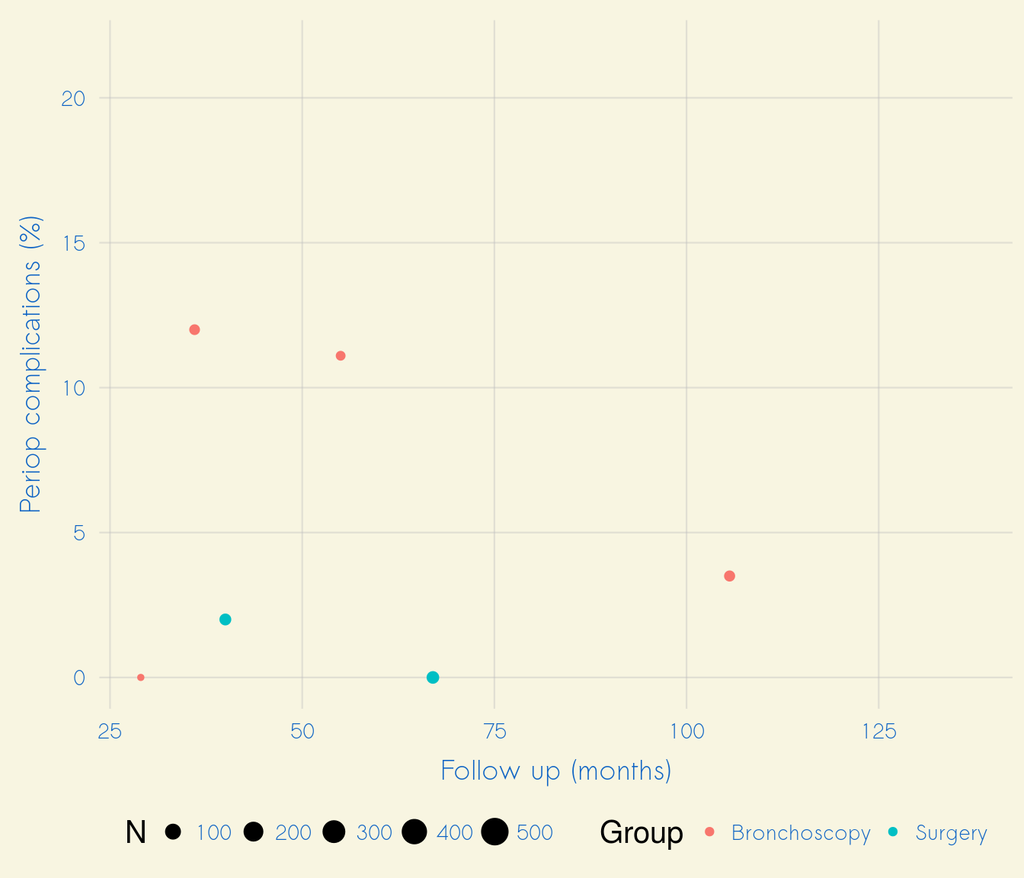

## Postoperative mortality (0%) over time

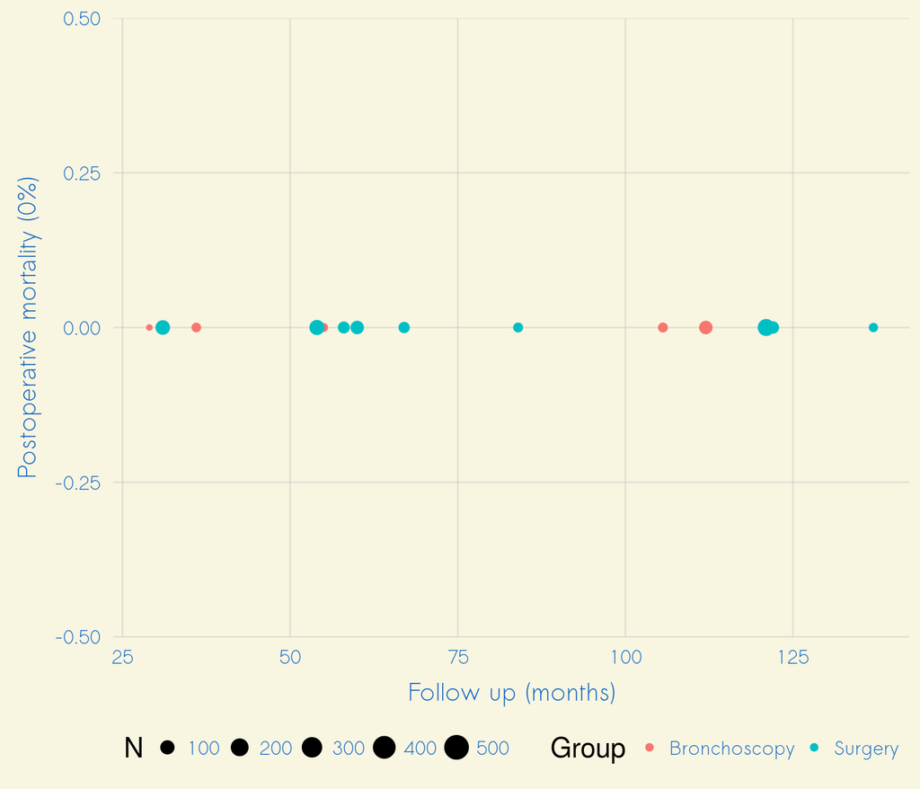

## Complete resection (%) over time

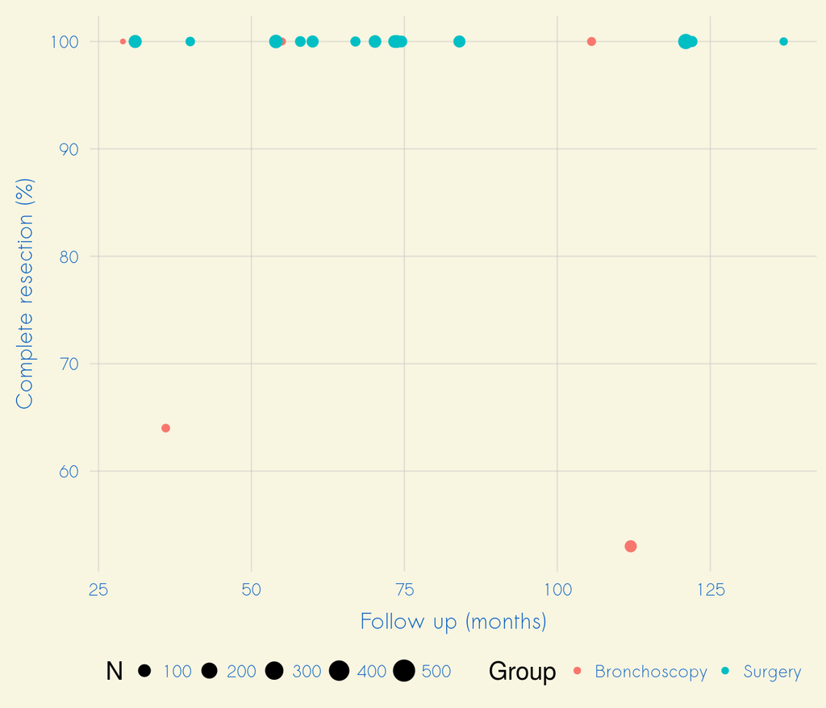

## Residual disease (%) over time

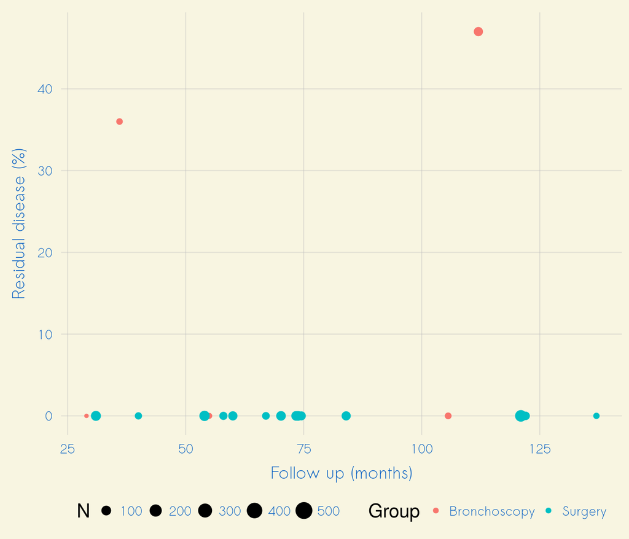

## Recurrence (%) over time

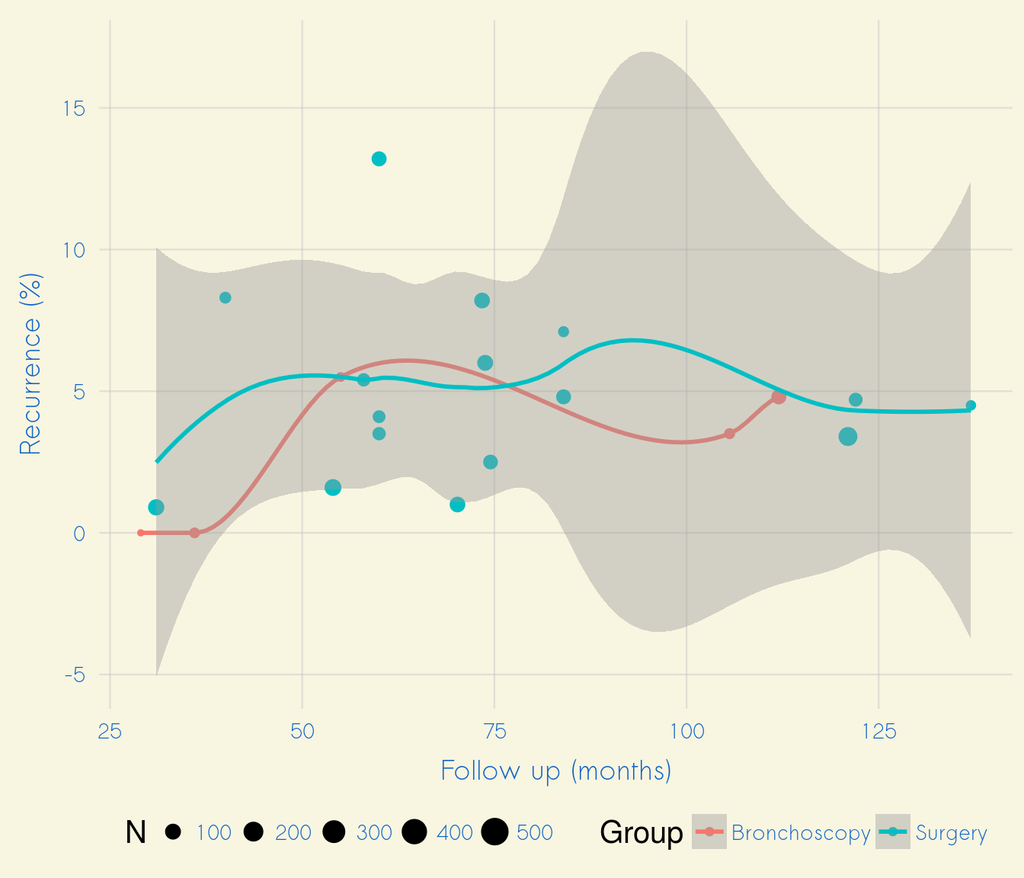

## Long term success rate

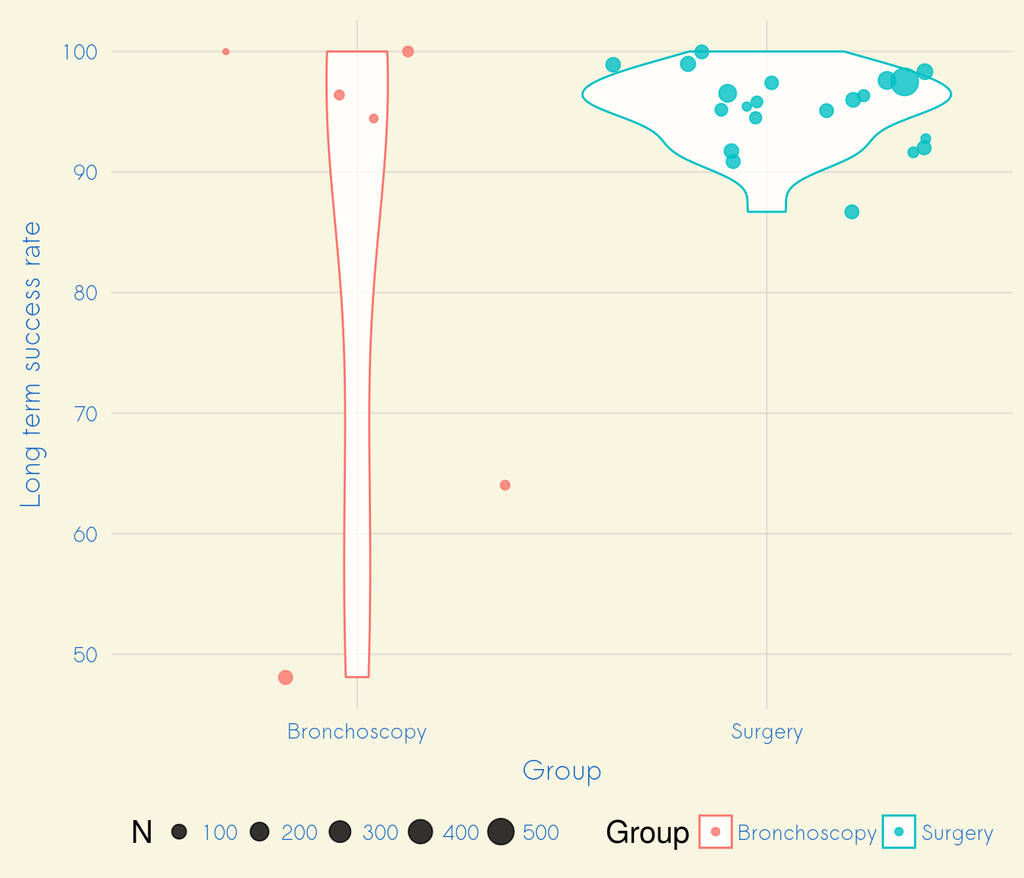

## 5 year survival rate

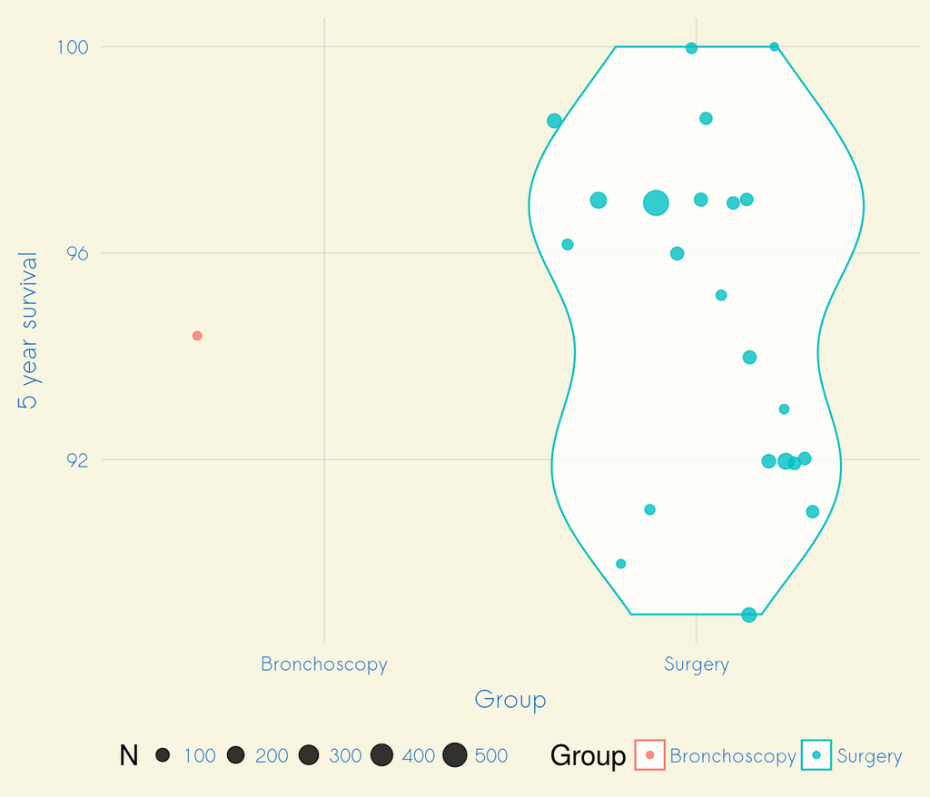

## 10 year survival rate

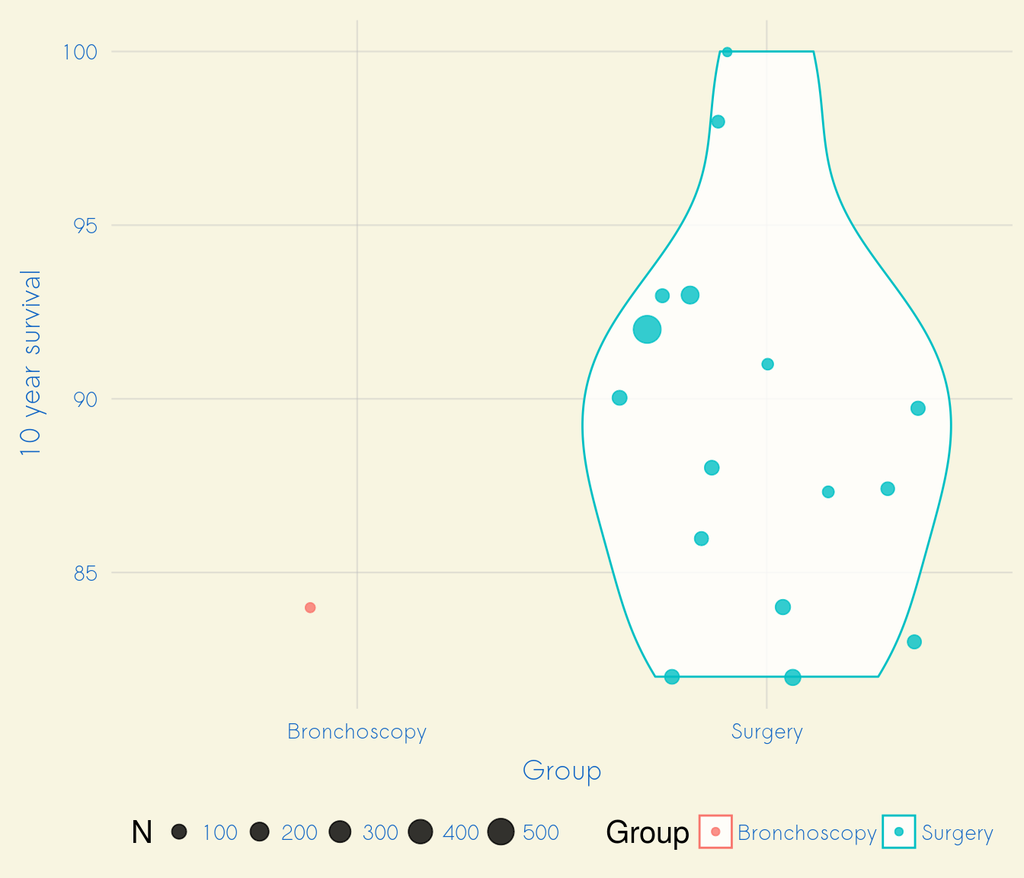

## Long term success rate by sex

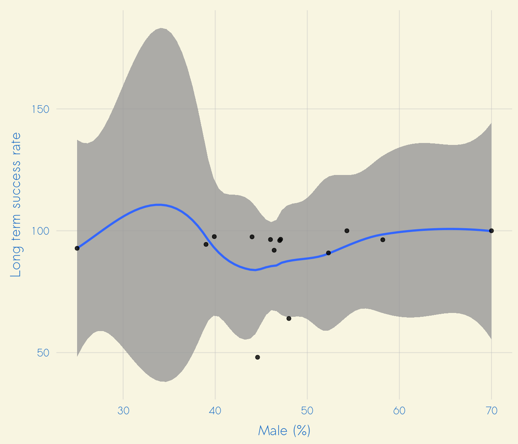

## Long term success rate by age

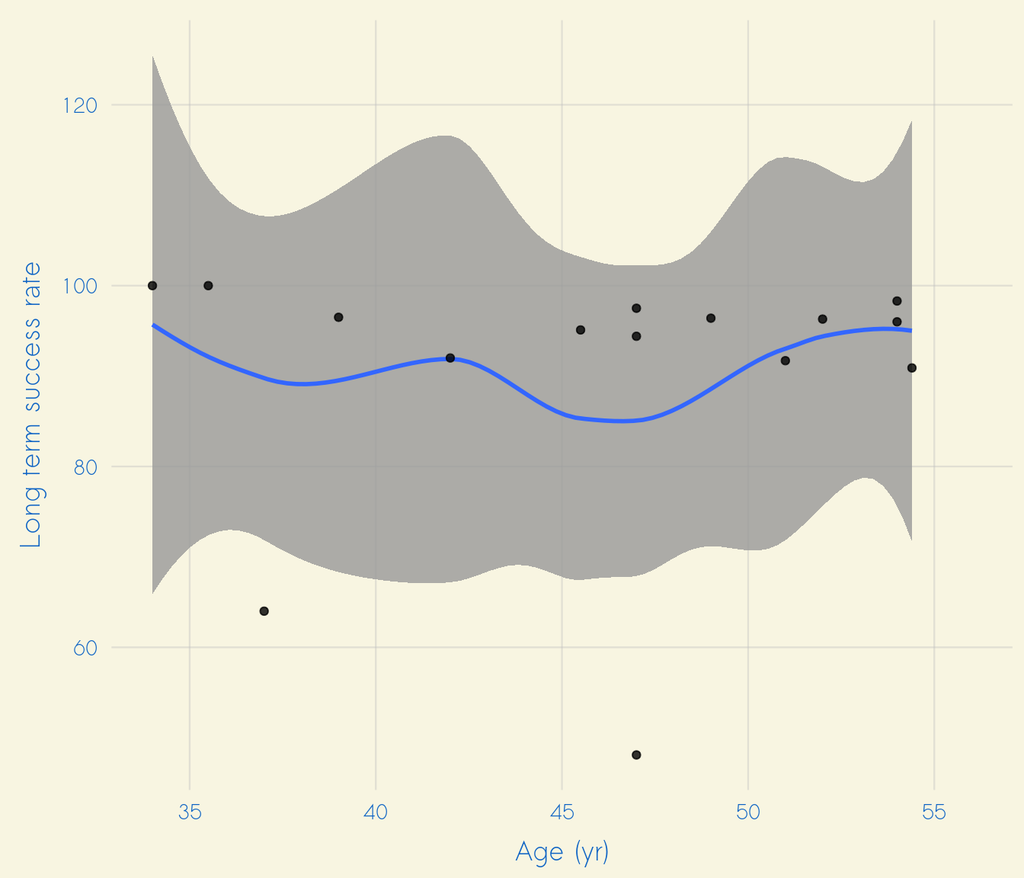

# Models

Are there statistically significant differences in the following outcome measures, as a function of the intervention type: Complete Resection, Residual Disease, Recurrence rate, Long tern successful rate and Survival

## Methods for modeling

Simple ordinary least squares, weighted by `N` (sample size), and adjusted for Age, Sex, and months followed up. Formulaically:

[output not shown]

The results are both tabular and graphical. In both, the “reference” group is Surgery (ie, the value shown is for Bronchoscopy). A p-value of less than 0.05, or a chart with the vertical uncertainty line not crossing the 0 line, is considered statistically significant. For survival outcomes, follow up months was removed from the right hand side of the equation.

We use the below R code to generate a model and plot for each outcome variable.

```r
# Define function for model
model <- function(outcome,
                  data){
  data$Group <- factor(data$Group, levels = c('Surgery', 'Bronchoscopy'))
  if(grepl('urvival', outcome)){
    the_formula <- paste0('`', outcome, '` ~ Group +',  '`Age (yr)` + `Male (%)`')
  } else {
    the_formula <- paste0('`', outcome, '` ~ Group +',  '`Age (yr)` + `Male (%)` + `Follow up (months)`')
  }

  the_formula <- as.formula(the_formula)
  fit <- lm(the_formula, weights = data$N, data = data)
  ci <- confint(fit)
  coefs <- coef(fit)
  out <-data.frame(coef = names(coefs), coefs, ci)
  out$coef <- gsub('Group', '', out$coef)
  row.names(out) <- NULL
  names(out) <- c('Variable', 'Coefficient', 'Lower', 'Upper')
  out$`P Value` <- summary(fit)$coefficients[,4]
  out_list <- list()
  out_list[[1]] <- out
  g <- ggplot(data = out %>%
                filter(Variable != '(Intercept)'),
              aes(x = Variable,
                  y = Coefficient)) +
    geom_point(color = 'red', alpha = 0.7) +
    geom_linerange(aes(x = Variable,
                       ymax = Upper,
                       ymin = Lower),
                   alpha = 0.7) +
    geom_hline(yintercept = 0, alpha = 0.7, lty = 2) +
    theme_databrew() +
    labs(title = '')
  out_list[[2]] <- g
  names(out_list) <- c('data', 'plot')
  return(out_list)
}
```

## Complete Resection

| Variable | Coefficient | Lower | Upper | P Value |
| --- | --- | --- | --- | --- |
| (Intercept) | 125.0639109 | -175.139620 | 425.2674415 | 0.3117853 |
| Bronchoscopy | -30.4362220 | -66.625501 | 5.7530570 | 0.0798078 |
| `Age (yr)` | -0.2882940 | -3.170034 | 2.5934461 | 0.7949618 |
| `Male (%)` | 0.0261304 | -3.473312 | 3.5255732 | 0.9844525 |
| `Follow up (months)` | -0.1375499 | -0.860241 | 0.5851412 | 0.6251539 |

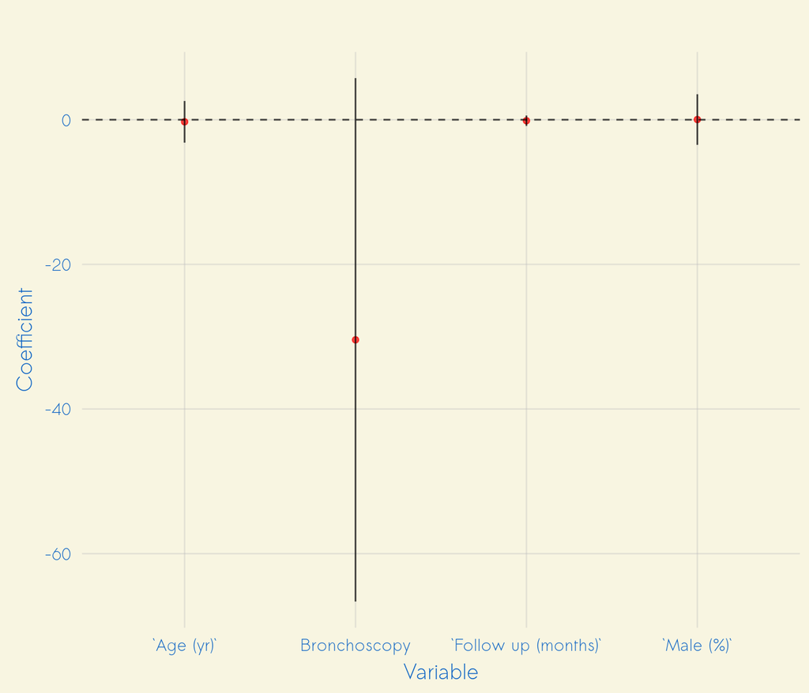

## Residual disease (%)

| Variable | Coefficient | Lower | Upper | P Value |
| --- | --- | --- | --- | --- |
| (Intercept) | -25.0639109 | -325.2674415 | 275.139620 | 0.8280656 |
| Bronchoscopy | 30.4362220 | -5.7530570 | 66.625501 | 0.0798078 |
| `Age (yr)` | 0.2882940 | -2.5934461 | 3.170034 | 0.7949618 |
| `Male (%)` | -0.0261304 | -3.5255732 | 3.473312 | 0.9844525 |
| `Follow up (months)` | 0.1375499 | -0.5851412 | 0.860241 | 0.6251539 |

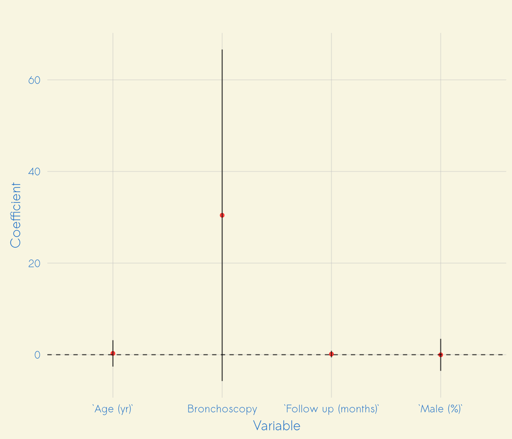

## Recurrence (%)

| Variable | Coefficient | Lower | Upper | P Value |
| --- | --- | --- | --- | --- |
| (Intercept) | -0.5248562 | -19.6031691 | 18.5534568 | 0.9357501 |
| Bronchoscopy | -0.6516225 | -2.9669016 | 1.6636566 | 0.4364231 |
| `Age (yr)` | 0.2022810 | 0.0247299 | 0.3798321 | 0.0361021 |
| `Male (%)` | -0.1186271 | -0.3568578 | 0.1196036 | 0.2112079 |
| `Follow up (months)` | 0.0133210 | -0.0330433 | 0.0596852 | 0.4279546 |

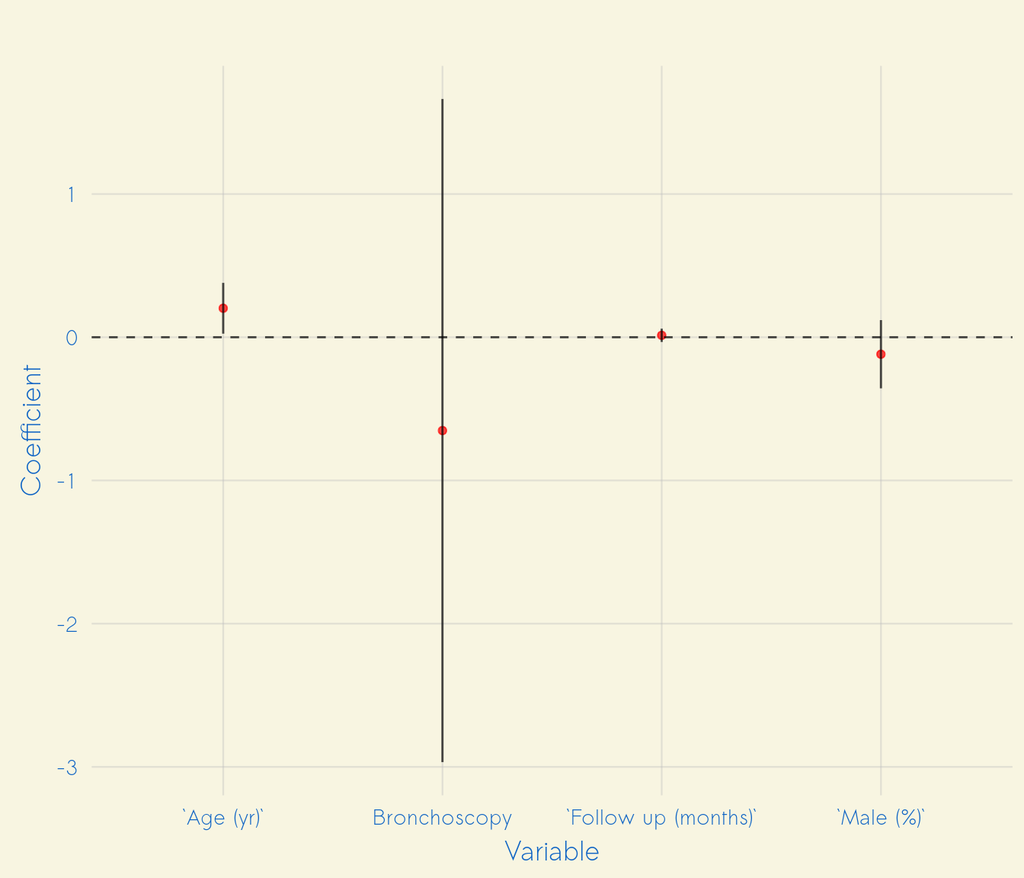

## Long term success rate

| Variable | Coefficient | Lower | Upper | P Value |
| --- | --- | --- | --- | --- |
| (Intercept) | 130.0521208 | -285.633091 | 545.7373326 | 0.3927979 |
| Bronchoscopy | -30.8869593 | -81.333101 | 19.5591829 | 0.1464834 |
| `Age (yr)` | -0.4205843 | -4.289131 | 3.4479628 | 0.7521913 |
| `Male (%)` | 0.0355561 | -5.155100 | 5.2262120 | 0.9839766 |
| `Follow up (months)` | -0.1683954 | -1.178597 | 0.8418062 | 0.6325267 |

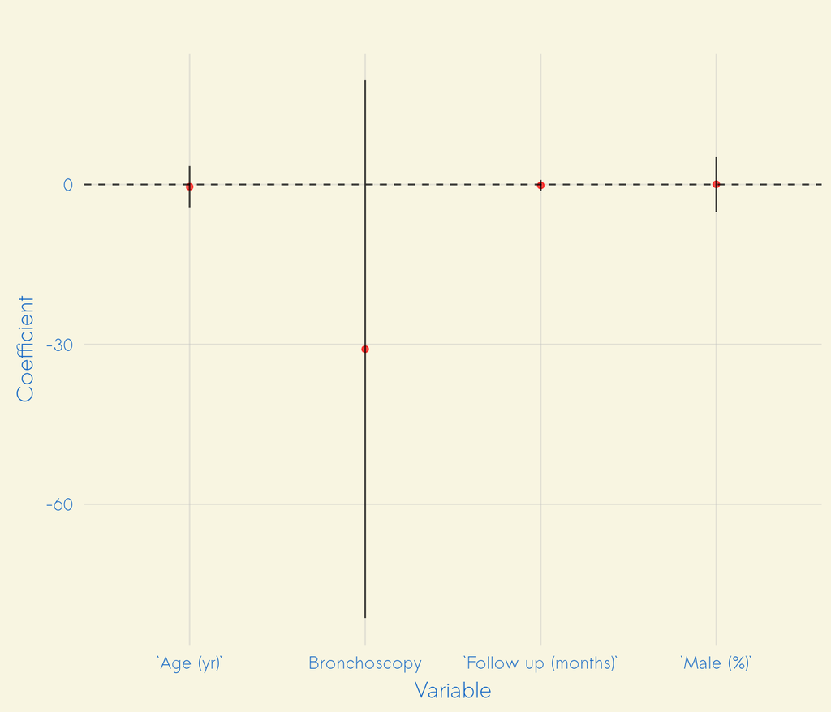

## 5 year survival

| Variable | Coefficient | Lower | Upper | P Value |
| --- | --- | --- | --- | --- |
| (Intercept) | 106.2644114 | 74.6262485 | 137.9025743 | 0.0003442 |
| Bronchoscopy | -2.6265853 | -17.9663325 | 12.7131620 | 0.6782018 |
| `Age (yr)` | -0.1222541 | -0.4888492 | 0.2443410 | 0.4304683 |
| `Male (%)` | -0.0982172 | -0.6254500 | 0.4290157 | 0.6522405 |

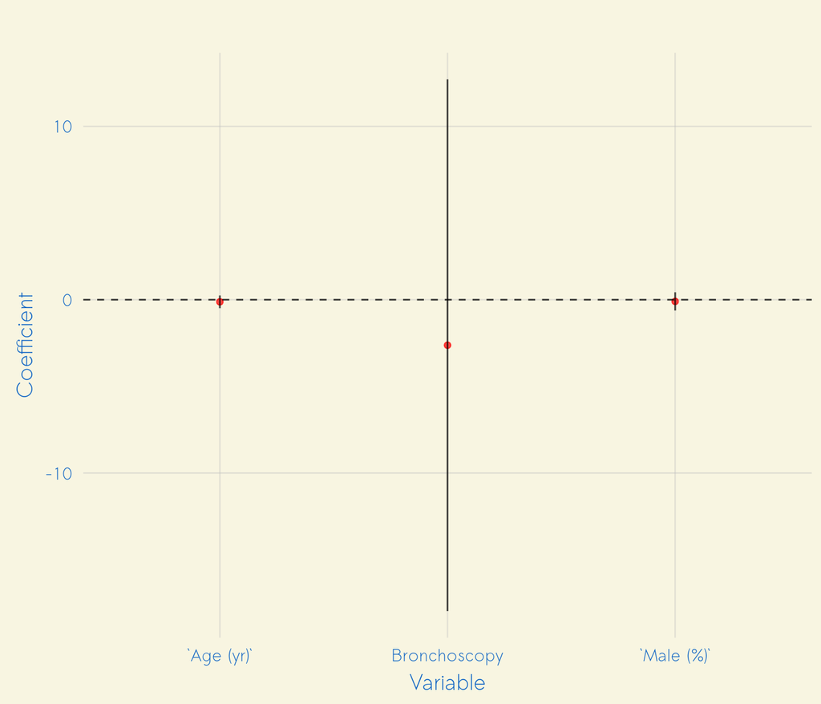

## 10 year survival

| Variable | Coefficient | Lower | Upper | P Value |
| --- | --- | --- | --- | --- |
| (Intercept) | 104.4176940 | 15.67568 | 193.1597033 | 0.0332392 |
| Bronchoscopy | -6.8723348 | -35.01647 | 21.2718045 | 0.4937483 |
| `Age (yr)` | -0.0215224 | -0.92624 | 0.8831953 | 0.9444179 |
| `Male (%)` | -0.2715383 | -2.08343 | 1.5403534 | 0.6659961 |

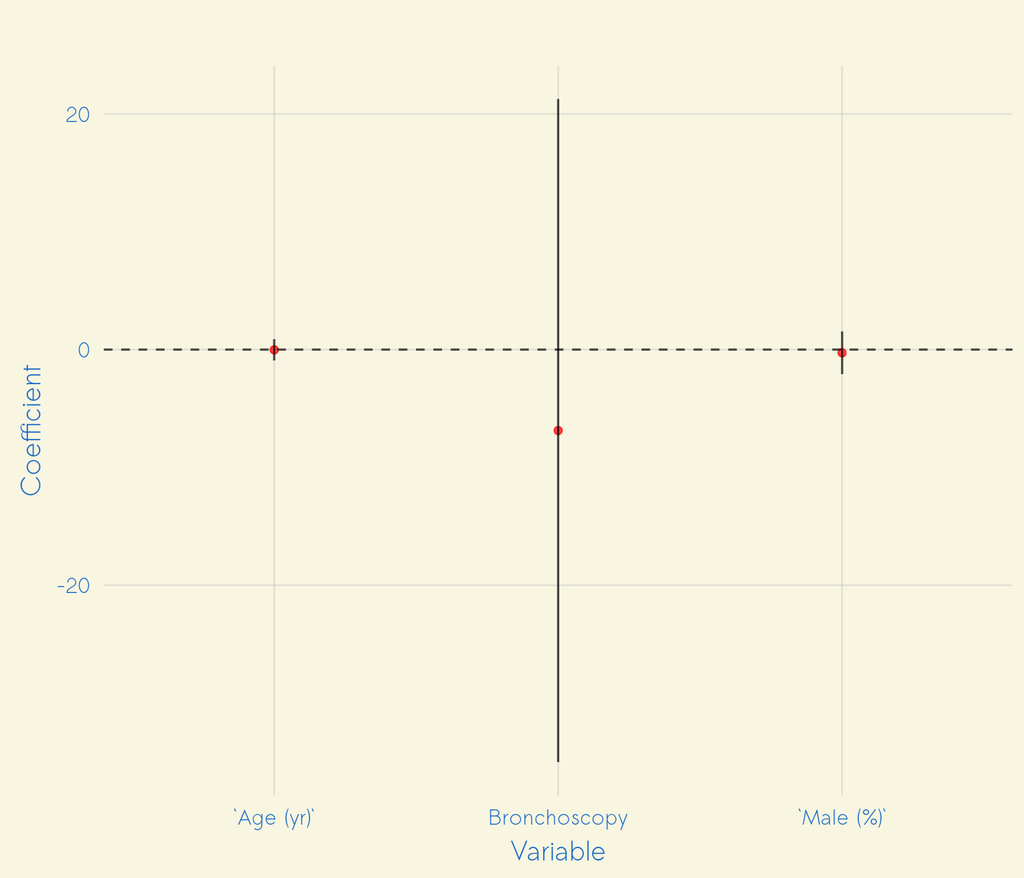